# hetoolkit-Vignette

## Model diagnostics

The `diag_lmer` function produces a variety of diagnostic plots for a mixed-effects regression (lmer) model.

```r
# generate diagnostic plots
diag_plots <- diag_lmer(model = model_3, data = autumn_data, facet_by = NULL)
```

These include:

1. Fitted vs observed values.

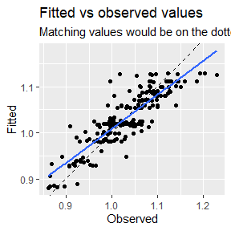

2. Normal probability plot.

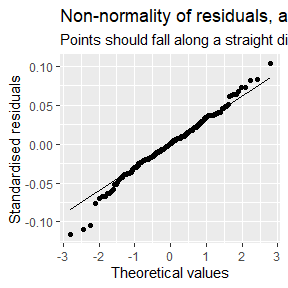

3. Residuals vs fitted.

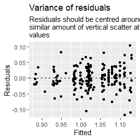

4. Histogram of residuals.

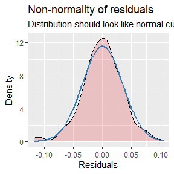

5. Residuals vs model fixed predictors. This displays a linear model (red) for each fixed predictor vs the model’s residuals. The blue line is a loess-smoothed line. The main purpose of this plot is to check whether or not the relationship between residuals and a predictor is linear.

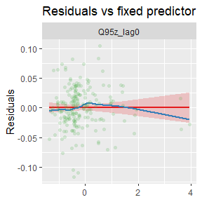

Alternatively, the plots can be faceted by site, to explore model fit and residuals site-by-site. In this example, the sites are arranged in descending order by the mean of the fitted values.

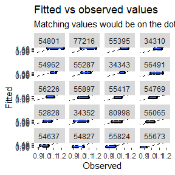

```r
# generate diagnostic plots
diag_plots2 <- diag_lmer(model = model_3,
                         data = autumn_data,
                         facet_by = "biol_site_id",
                         order_by = "mean",
                         order = "descending",
                         ncol = 4,
                         scales = "fixed")

diag_plots2[[1]]
```

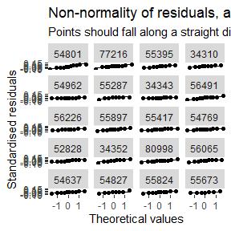

```r
diag_plots2[[2]]
```

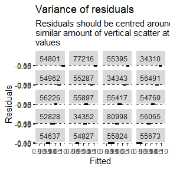

```r
diag_plots2[[3]]
```

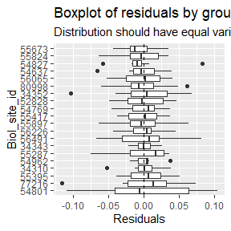

```r
# boxplot instead of histogram of residuals:
diag_plots2[[4]]
```

```r
# same as un-faceted option:
# diag_plots2[[5]]
```

Other useful diagnostic plots for `lmer` models include:

- caterpillar plots, for visualising the random intercepts and slopes for each site:

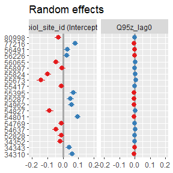

```r
sjPlot::plot_model(model = model_3,
                   type = "re",
                   facet.grid = FALSE,
                   free.scale = FALSE,
                   title = NULL,
                   vline.color = "darkgrey") +
  ylim(-0.2,0.2)
```

- partial regression plot for a fixed effect, showing the ‘global’ relationship:

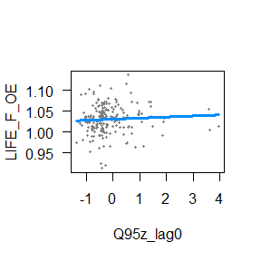

```r
visreg::visreg(model_3, "Q95z_lag0", ylab = "LIFE_F_OE")
```

- partial regression plot for a random effect, showing the site-specific relationship:

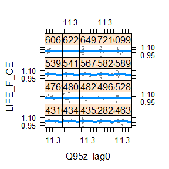

```r
visreg::visreg(model_2, "Q95z_lag0", by = "biol_site_id", ylab = "LIFE_F_OE")
```

## Predictions

The `plot_predictions` function produces a time series plot of predictions from a hydro-ecological model, alongside observed biology and flow data. The plot is faceted by site, as specified by the `site_col` argument. The function generates a ggplot object, which can optionally be saved as a .png file named “Predictions_Plot.png”.

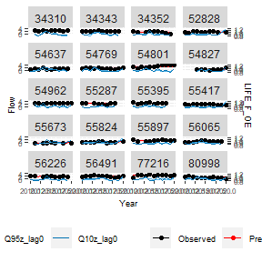

```r
# Generate prediction intervals
pi <- merTools::predictInterval(merMod = model_3,
                                level = 0.95,
                                n.sims = 1000,
                                stat = "mean",
                                type="linear.prediction",
                                include.resid.var = TRUE)

# bind to model calibration dataset
autumn_data <- cbind(autumn_data, pi)

# produce predictions plot
plot_predictions(data = autumn_data,
                  biol_metric = "LIFE_F_OE",
                  time_col = "Year",
                  site_col = "biol_site_id",
                  flow_stat = c("Q95z_lag0", "Q10z_lag0"),
                  pred_col = c("fit", "lwr", "upr"),
                  ncol = 4)
```